# Regression Model diagnostics: N of students prediction

by JUMEX365

## All packages

```r
library(foreign)
library(dplyr)
```

```r
library(readr)
library(psych)
library(ggplot2)
library(MASS)
library(car)
library(nortest)
```

## Loading and editing data

```r
data1 = read.spss("HBSC 2014 5 countries.sav",
                    to.data.frame=TRUE)


data1$friendshare <- as.numeric(data1$friendshare)
data1$friendtalk <- as.numeric(data1$friendtalk)
data1$friendhelp <- as.numeric(data1$friendhelp)
data1$friendcounton <- as.numeric(data1$friendcounton)
```

## Variables

*Dependent variable*

```r
data1$studentsINschool <- rowMeans(data1[,c(65:67)], na.rm=TRUE)
```

*Independent variable*

```r
data1$goodFriends <- rowMeans(data1[,c(51:54)], na.rm=TRUE)
```

## Descriptive statistics

```r
##Creating function for defining mode (note, that it is exclude NA values)
function.mode <- function(x) {
  theonly <- na.omit(unique(x))
  theonly[which.max(tabulate(match(x, theonly,  nomatch = NA_integer_, incomparables = NULL)))]
}
```

### dependent variable

```r
describe(data1$studentsINschool)
```

```
##    vars     n mean   sd median trimmed  mad min max range skew kurtosis se
## X1    1 25753 2.09 0.79      2    2.02 0.49   1   5     4 0.84      0.9  0
```

```r
#mode
function.mode(data1$studentsINschool)
```

```
## [1] 2
```

Description:

- According to high skew and kurtosis values - distribution is not normal.
- Median: 2; Mean: 2.09; Mode: 2. All values is really similar, that is good sign.
- Min value is 1, while max is 5.

Histogram allows to track the distribution of values

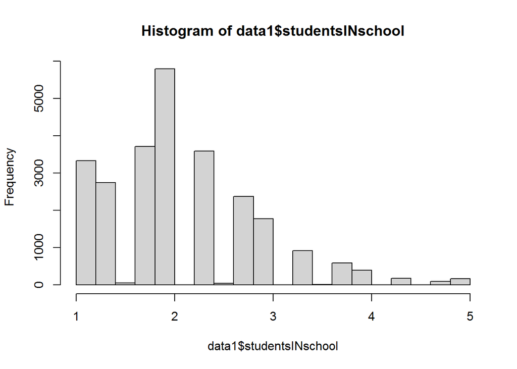

```r
hist(data1$studentsINschool)
```

### Independent variable

```r
describe(data1$goodFriends)
```

```
##    vars     n mean   sd median trimmed  mad min max range  skew kurtosis   se
## X1    1 25629 5.49 1.57      6    5.74 1.48   1   7     6 -1.18     0.71 0.01
```

```r
#mode
function.mode(data1$goodFriends)
```

```
## [1] 7
```

- According to high skew and kurtosis values - distribution is not normal.
- Median: 6; Mean: 5.49; Mode: 7. Values deviates from each other significantly.
- Min value is 1, while max is 7.

Also create histogram for understanding.

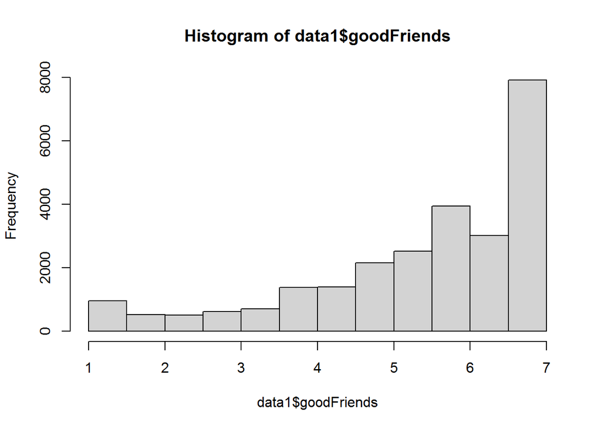

```r
hist(data1$goodFriends)
```

### Auxiliary variable for the model - just in case

### Age

```r
describe(data1$AGE)
```

```
##    vars     n  mean   sd median trimmed  mad  min  max range  skew kurtosis
## X1    1 25838 13.52 1.66   13.5   13.52 2.47 10.5 16.5     6 -0.03    -1.31
##      se
## X1 0.01
```

```r
#mode
function.mode(data1$AGE)
```

```
## [1] 11.5
```

## Description of the results of the model

```r
model1 <- lm(studentsINschool ~ as.factor(sex) +
                as.numeric(AGE) + as.factor(m96) +
                as.factor(bulliedothers) *
                as.numeric(goodFriends), data1)
summary(model1)
```

```
##
## Call:
## lm(formula = studentsINschool ~ as.factor(sex) + as.numeric(AGE) +
##     as.factor(m96) + as.factor(bulliedothers) * as.numeric(goodFriends),
##     data = data1)
##
## Residuals:
##     Min      1Q  Median      3Q     Max
## -1.9741 -0.5173 -0.0707  0.3978  3.3985
##
## Coefficients:
##                                                                      Estimate
## (Intercept)                                                          2.081245
## as.factor(sex)Girl                                                   0.137504
## as.numeric(AGE)                                                      0.054484
## as.factor(m96)Less than weekly                                      -0.056951
## as.factor(m96)Weekly                                                -0.092370
## as.factor(m96)Daily (specified in own variable)                     -0.101969
## as.factor(bulliedothers)Once or twice                               -0.036925
## as.factor(bulliedothers)2-3 times per month                         -0.071616
## as.factor(bulliedothers)Once/week                                   -0.067567
## as.factor(bulliedothers)Several times/week                           0.164048
## as.numeric(goodFriends)                                             -0.145370
## as.factor(bulliedothers)Once or twice:as.numeric(goodFriends)        0.030137
## as.factor(bulliedothers)2-3 times per month:as.numeric(goodFriends)  0.040354
## as.factor(bulliedothers)Once/week:as.numeric(goodFriends)            0.047986
## as.factor(bulliedothers)Several times/week:as.numeric(goodFriends)   0.016073
##                                                                     Std. Error
## (Intercept)                                                           0.045558
## as.factor(sex)Girl                                                    0.009862
## as.numeric(AGE)                                                       0.003022
## as.factor(m96)Less than weekly                                        0.012107
## as.factor(m96)Weekly                                                  0.013490
## as.factor(m96)Daily (specified in own variable)                       0.019353
## as.factor(bulliedothers)Once or twice                                 0.045003
## as.factor(bulliedothers)2-3 times per month                           0.080471
## as.factor(bulliedothers)Once/week                                     0.108782
## as.factor(bulliedothers)Several times/week                            0.087857
## as.numeric(goodFriends)                                               0.003762
## as.factor(bulliedothers)Once or twice:as.numeric(goodFriends)         0.007955
```

[output cut: 43 more lines]

```
## as.factor(bulliedothers)2-3 times per month
## as.factor(bulliedothers)Once/week
## as.factor(bulliedothers)Several times/week                          .
## as.numeric(goodFriends)                                             ***
## as.factor(bulliedothers)Once or twice:as.numeric(goodFriends)       ***
## as.factor(bulliedothers)2-3 times per month:as.numeric(goodFriends) **
## as.factor(bulliedothers)Once/week:as.numeric(goodFriends)           *
## as.factor(bulliedothers)Several times/week:as.numeric(goodFriends)
## ---
## Signif. codes:  0 '***' 0.001 '**' 0.01 '*' 0.05 '.' 0.1 ' ' 1
##
## Residual standard error: 0.7463 on 24275 degrees of freedom
##   (1812 observations deleted due to missingness)
## Multiple R-squared:  0.09717,    Adjusted R-squared:  0.09665
## F-statistic: 186.6 on 14 and 24275 DF,  p-value: < 2.2e-16
```

Description: While all other variables of model = 0 - Girls have higher value of `studentsINschool` (on ~0.14 points). This effect is positive and statistically significant.

- Each extra point of `Age` on average increase value of `studentsINschool`(on ~0.05). Effect is positive and statistically significant.
- Response on variable `m96` “Less than weekly” on average decrease value of `studentsINschool` (on ~ -0.06). Effect is negative and statistically significant.
- Response on variable `m96` “Weekly” on average decrease value of `studentsINschool` (on ~ -0.09). Effect is negative and statistically significant.
- Response on variable `m96` “Daily” on average decrease value of `studentsINschool` (on ~ -0.1). Effect is negative and statistically significant.
- Other responses on variable `m96` in not statistically significant.

Interaction:

- Each extra point of `goodFriends` value on average increase value of `studentsINschool`(on ~ -0.15). Effect is negative and statistically significant.
- Response on variable `bulliedothers` “once/twice” on average increase value of `studentsINschool` (on ~0.03). Effect is positive and statistically significant.
- Response on variable `bulliedothers` “2-3 times / month” on average increase value of `studentsINschool` (on ~0.04). Effect is positive and statistically significant.
- Response on variable `bulliedothers` “Once/week” on average increase value of `studentsINschool` (on ~0.05). Effect is positive and statistically significant.
- Response on variable `bulliedothers` “Several times” is not statistically significant.

Generally, model is bad because it explains only ~ 10% of observations. (r^2=0.09665)

## Model diagnostics

### Normality residuals test

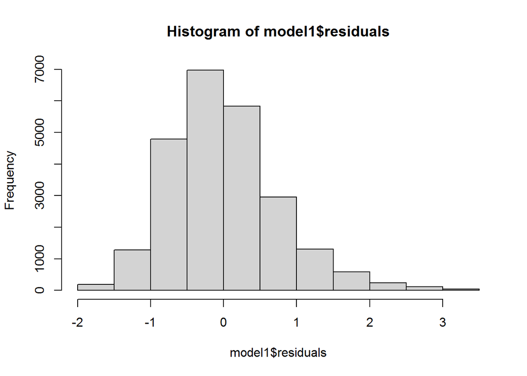

```r
hist(model1$residuals)
```

From histogram, it may me noted that distribution is little-bit skewed, but look like normal. Let’s perform formal test.

```r
lillie.test(model1$residuals)
```

```
##
##  Lilliefors (Kolmogorov-Smirnov) normality test
##
## data:  model1$residuals
## D = 0.05587, p-value < 2.2e-16
```

Null hypothesis: distribution is normal.

P-value < 2.2e-16, so we reject null hypothesis.

Residuals is distributed not normally. *Problem identified.*

### Multicollinearity test

```r
vif(model1)
```

```
##                                                          GVIF Df
## as.factor(sex)                                       1.059857  1
## as.numeric(AGE)                                      1.090730  1
## as.factor(m96)                                       1.130199  3
## as.factor(bulliedothers)                         13640.568693  4
## as.numeric(goodFriends)                              1.487468  1
## as.factor(bulliedothers):as.numeric(goodFriends) 13695.068608  4
##                                                  GVIF^(1/(2*Df))
## as.factor(sex)                                          1.029494
## as.numeric(AGE)                                         1.044380
## as.factor(m96)                                          1.020608
## as.factor(bulliedothers)                                3.287411
## as.numeric(goodFriends)                                 1.219618
## as.factor(bulliedothers):as.numeric(goodFriends)        3.289050
```

For SEX, AGE, M96 all is fine < 4.

However, this is multicollinearity for bulliedothers and its interaction. *Issue identified*

### Heteroscedasticity test

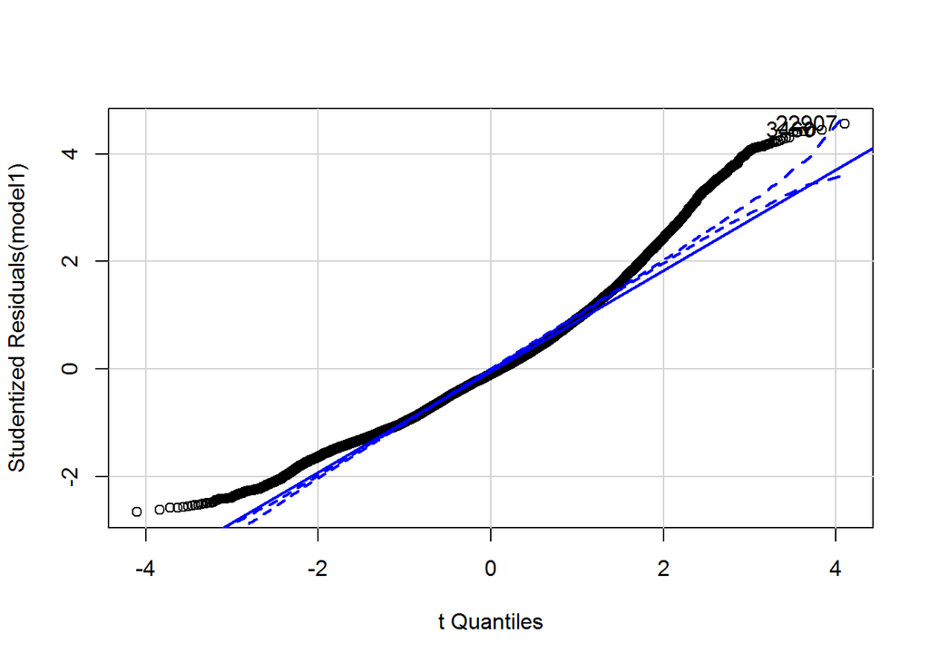

```
## [1]  3460 22907
```

```r
qqPlot(model1)
```

Residuals significantly deviates from “blue” area, there is some issues with heteroscedasticity.

Let’s perform formal test

```r
ncvTest(model1)
```

```
## Non-constant Variance Score Test
## Variance formula: ~ fitted.values
## Chisquare = 595.879, Df = 1, p = < 2.22e-16
```

P-value < 2.2e-16, so we reject null hypothesis. THere is some problems with heteroscedasticity. *Issue identified.*

### Outliers test.

```r
outlierTest(model1)
```

```
## No Studentized residuals with Bonferroni p < 0.05
## Largest |rstudent|:
##       rstudent unadjusted p-value Bonferroni p
## 22907 4.556663         5.2226e-06      0.12686
```

Null hypothesis: There is no extreme outliers in residuals.

All the Bonferroni p > 0.05, so we cannot reject Null hypothesis. There are no extreme outliers. *Fine*

### Linearity of relationships test

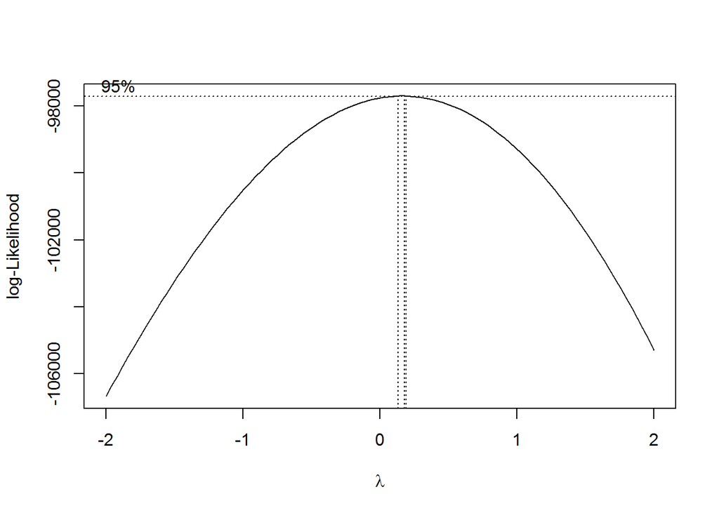

```r
boxcox(model1)
```

Values are closer to 0(than to 1), so it is sign to make transformation of the dependent variable.

### Model fix

Based on previous finding it is good idea to take logarithm from dependent variable.

```r
data1$LOGstudentsINschool <- log(data1$studentsINschool)

model2 <- lm(LOGstudentsINschool ~ as.factor(sex) +
                as.numeric(AGE) + as.factor(m96) +
                as.factor(bulliedothers) *
                as.numeric(goodFriends), data1)
summary(model2)
```

```
##
## Call:
## lm(formula = LOGstudentsINschool ~ as.factor(sex) + as.numeric(AGE) +
##     as.factor(m96) + as.factor(bulliedothers) * as.numeric(goodFriends),
##     data = data1)
##
## Residuals:
##      Min       1Q   Median       3Q      Max
## -1.06691 -0.23021  0.02924  0.23883  1.17274
##
## Coefficients:
##                                                                      Estimate
## (Intercept)                                                          0.636320
## as.factor(sex)Girl                                                   0.063954
## as.numeric(AGE)                                                      0.027813
## as.factor(m96)Less than weekly                                      -0.019559
## as.factor(m96)Weekly                                                -0.042534
## as.factor(m96)Daily (specified in own variable)                     -0.057996
## as.factor(bulliedothers)Once or twice                               -0.017220
## as.factor(bulliedothers)2-3 times per month                         -0.036144
## as.factor(bulliedothers)Once/week                                   -0.060235
## as.factor(bulliedothers)Several times/week                          -0.026479
## as.numeric(goodFriends)                                             -0.069099
## as.factor(bulliedothers)Once or twice:as.numeric(goodFriends)        0.015318
## as.factor(bulliedothers)2-3 times per month:as.numeric(goodFriends)  0.019550
## as.factor(bulliedothers)Once/week:as.numeric(goodFriends)            0.027757
## as.factor(bulliedothers)Several times/week:as.numeric(goodFriends)   0.022629
##                                                                     Std. Error
## (Intercept)                                                           0.021928
## as.factor(sex)Girl                                                    0.004747
## as.numeric(AGE)                                                       0.001455
## as.factor(m96)Less than weekly                                        0.005827
## as.factor(m96)Weekly                                                  0.006493
## as.factor(m96)Daily (specified in own variable)                       0.009315
## as.factor(bulliedothers)Once or twice                                 0.021661
## as.factor(bulliedothers)2-3 times per month                           0.038732
## as.factor(bulliedothers)Once/week                                     0.052359
## as.factor(bulliedothers)Several times/week                            0.042287
## as.numeric(goodFriends)                                               0.001811
## as.factor(bulliedothers)Once or twice:as.numeric(goodFriends)         0.003829
```

[output cut: 43 more lines]

```
## as.factor(bulliedothers)2-3 times per month
## as.factor(bulliedothers)Once/week
## as.factor(bulliedothers)Several times/week
## as.numeric(goodFriends)                                             ***
## as.factor(bulliedothers)Once or twice:as.numeric(goodFriends)       ***
## as.factor(bulliedothers)2-3 times per month:as.numeric(goodFriends) **
## as.factor(bulliedothers)Once/week:as.numeric(goodFriends)           **
## as.factor(bulliedothers)Several times/week:as.numeric(goodFriends)  **
## ---
## Signif. codes:  0 '***' 0.001 '**' 0.01 '*' 0.05 '.' 0.1 ' ' 1
##
## Residual standard error: 0.3592 on 24275 degrees of freedom
##   (1812 observations deleted due to missingness)
## Multiple R-squared:  0.09497,    Adjusted R-squared:  0.09445
## F-statistic:   182 on 14 and 24275 DF,  p-value: < 2.2e-16
```

Description:

### Heteroscedasticity test

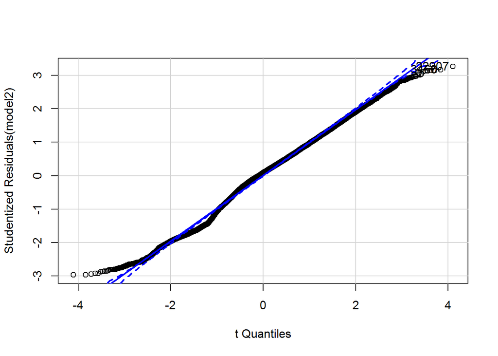

```
## [1]  3460 22907
```

```r
qqPlot(model2)
```

Residuals deviates from “blue” area insignificantly, there is less issues with heteroscedasticity.

- There is improvement.